# Risk Factor Analysis

## Outcome Variable

**Outcome Variable:** ever_stunted

## Predictor Variables

**Intervention Variable:** fage

**Adjustment Set:**

unadjusted

## Stratifying Variables

The analysis was stratified on these variable(s):

- agecat
- studyid
- country

## Data Summary

| agecat | studyid | country | A | n | nA | nAY0 | nAY1 |
| --- | --- | --- | --- | --- | --- | --- | --- |
| 3 months | ki0047075b-MAL-ED | BANGLADESH | >=35 | 151 | 102 | 77 | 25 |
| 3 months | ki0047075b-MAL-ED | BANGLADESH | <25 | 151 | 0 | 0 | 0 |
| 3 months | ki0047075b-MAL-ED | BANGLADESH | [25-30) | 151 | 14 | 7 | 7 |
| 3 months | ki0047075b-MAL-ED | BANGLADESH | [30-35) | 151 | 35 | 29 | 6 |
| 3 months | ki0047075b-MAL-ED | BRAZIL | >=35 | 79 | 40 | 36 | 4 |
| 3 months | ki0047075b-MAL-ED | BRAZIL | <25 | 79 | 3 | 2 | 1 |
| 3 months | ki0047075b-MAL-ED | BRAZIL | [25-30) | 79 | 8 | 8 | 0 |
| 3 months | ki0047075b-MAL-ED | BRAZIL | [30-35) | 79 | 28 | 21 | 7 |
| 3 months | ki0047075b-MAL-ED | INDIA | >=35 | 161 | 71 | 52 | 19 |
| 3 months | ki0047075b-MAL-ED | INDIA | <25 | 161 | 3 | 1 | 2 |
| 3 months | ki0047075b-MAL-ED | INDIA | [25-30) | 161 | 27 | 20 | 7 |
| 3 months | ki0047075b-MAL-ED | INDIA | [30-35) | 161 | 60 | 43 | 17 |
| 3 months | ki0047075b-MAL-ED | NEPAL | >=35 | 79 | 38 | 32 | 6 |
| 3 months | ki0047075b-MAL-ED | NEPAL | <25 | 79 | 0 | 0 | 0 |
| 3 months | ki0047075b-MAL-ED | NEPAL | [25-30) | 79 | 10 | 9 | 1 |
| 3 months | ki0047075b-MAL-ED | NEPAL | [30-35) | 79 | 31 | 26 | 5 |
| 3 months | ki0047075b-MAL-ED | PERU | >=35 | 85 | 45 | 31 | 14 |
| 3 months | ki0047075b-MAL-ED | PERU | <25 | 85 | 5 | 3 | 2 |
| 3 months | ki0047075b-MAL-ED | PERU | [25-30) | 85 | 18 | 12 | 6 |
| 3 months | ki0047075b-MAL-ED | PERU | [30-35) | 85 | 17 | 8 | 9 |
| 3 months | ki0047075b-MAL-ED | SOUTH AFRICA | >=35 | 90 | 75 | 58 | 17 |
| 3 months | ki0047075b-MAL-ED | SOUTH AFRICA | <25 | 90 | 1 | 1 | 0 |
| 3 months | ki0047075b-MAL-ED | SOUTH AFRICA | [25-30) | 90 | 6 | 4 | 2 |
| 3 months | ki0047075b-MAL-ED | SOUTH AFRICA | [30-35) | 90 | 8 | 7 | 1 |
| 3 months | ki0047075b-MAL-ED | TANZANIA, UNITED REPUBLIC OF | >=35 | 100 | 65 | 44 | 21 |
| 3 months | ki0047075b-MAL-ED | TANZANIA, UNITED REPUBLIC OF | <25 | 100 | 2 | 0 | 2 |
| 3 months | ki0047075b-MAL-ED | TANZANIA, UNITED REPUBLIC OF | [25-30) | 100 | 6 | 1 | 5 |
| 3 months | ki0047075b-MAL-ED | TANZANIA, UNITED REPUBLIC OF | [30-35) | 100 | 27 | 21 | 6 |
| 3 months | ki1135781-COHORTS | GUATEMALA | >=35 | 492 | 198 | 139 | 59 |
| 3 months | ki1135781-COHORTS | GUATEMALA | <25 | 492 | 81 | 66 | 15 |

[output cut: 182 more lines]

The following strata were considered:

- agecat: 12 months, studyid: ki0047075b-MAL-ED, country: BANGLADESH
- agecat: 12 months, studyid: ki0047075b-MAL-ED, country: BRAZIL
- agecat: 12 months, studyid: ki0047075b-MAL-ED, country: INDIA
- agecat: 12 months, studyid: ki0047075b-MAL-ED, country: NEPAL
- agecat: 12 months, studyid: ki0047075b-MAL-ED, country: PERU
- agecat: 12 months, studyid: ki0047075b-MAL-ED, country: SOUTH AFRICA
- agecat: 12 months, studyid: ki0047075b-MAL-ED, country: TANZANIA, UNITED REPUBLIC OF
- agecat: 12 months, studyid: ki1000304b-SAS-FoodSuppl, country: INDIA
- agecat: 12 months, studyid: ki1135781-COHORTS, country: GUATEMALA
- agecat: 12 months, studyid: ki1135781-COHORTS, country: PHILIPPINES
- agecat: 12 months, studyid: ki1148112-LCNI-5, country: MALAWI
- agecat: 18 months, studyid: ki0047075b-MAL-ED, country: BANGLADESH
- agecat: 18 months, studyid: ki0047075b-MAL-ED, country: BRAZIL
- agecat: 18 months, studyid: ki0047075b-MAL-ED, country: INDIA
- agecat: 18 months, studyid: ki0047075b-MAL-ED, country: NEPAL
- agecat: 18 months, studyid: ki0047075b-MAL-ED, country: PERU
- agecat: 18 months, studyid: ki0047075b-MAL-ED, country: SOUTH AFRICA
- agecat: 18 months, studyid: ki0047075b-MAL-ED, country: TANZANIA, UNITED REPUBLIC OF
- agecat: 18 months, studyid: ki1000304b-SAS-FoodSuppl, country: INDIA
- agecat: 18 months, studyid: ki1135781-COHORTS, country: GUATEMALA
- agecat: 18 months, studyid: ki1135781-COHORTS, country: PHILIPPINES
- agecat: 18 months, studyid: ki1148112-LCNI-5, country: MALAWI
- agecat: 24 months, studyid: ki0047075b-MAL-ED, country: BANGLADESH
- agecat: 24 months, studyid: ki0047075b-MAL-ED, country: BRAZIL
- agecat: 24 months, studyid: ki0047075b-MAL-ED, country: INDIA
- agecat: 24 months, studyid: ki0047075b-MAL-ED, country: NEPAL
- agecat: 24 months, studyid: ki0047075b-MAL-ED, country: PERU
- agecat: 24 months, studyid: ki0047075b-MAL-ED, country: SOUTH AFRICA
- agecat: 24 months, studyid: ki0047075b-MAL-ED, country: TANZANIA, UNITED REPUBLIC OF
- agecat: 24 months, studyid: ki1000304b-SAS-FoodSuppl, country: INDIA
- agecat: 24 months, studyid: ki1135781-COHORTS, country: GUATEMALA
- agecat: 24 months, studyid: ki1135781-COHORTS, country: PHILIPPINES
- agecat: 24 months, studyid: ki1148112-LCNI-5, country: MALAWI
- agecat: 3 months, studyid: ki0047075b-MAL-ED, country: BANGLADESH
- agecat: 3 months, studyid: ki0047075b-MAL-ED, country: BRAZIL
- agecat: 3 months, studyid: ki0047075b-MAL-ED, country: INDIA
- agecat: 3 months, studyid: ki0047075b-MAL-ED, country: NEPAL
- agecat: 3 months, studyid: ki0047075b-MAL-ED, country: PERU
- agecat: 3 months, studyid: ki0047075b-MAL-ED, country: SOUTH AFRICA
- agecat: 3 months, studyid: ki0047075b-MAL-ED, country: TANZANIA, UNITED REPUBLIC OF
- agecat: 3 months, studyid: ki1135781-COHORTS, country: GUATEMALA
- agecat: 3 months, studyid: ki1135781-COHORTS, country: PHILIPPINES
- agecat: 6 months, studyid: ki0047075b-MAL-ED, country: BANGLADESH
- agecat: 6 months, studyid: ki0047075b-MAL-ED, country: BRAZIL
- agecat: 6 months, studyid: ki0047075b-MAL-ED, country: INDIA
- agecat: 6 months, studyid: ki0047075b-MAL-ED, country: NEPAL
- agecat: 6 months, studyid: ki0047075b-MAL-ED, country: PERU
- agecat: 6 months, studyid: ki0047075b-MAL-ED, country: SOUTH AFRICA
- agecat: 6 months, studyid: ki0047075b-MAL-ED, country: TANZANIA, UNITED REPUBLIC OF
- agecat: 6 months, studyid: ki1000304b-SAS-FoodSuppl, country: INDIA
- agecat: 6 months, studyid: ki1135781-COHORTS, country: GUATEMALA
- agecat: 6 months, studyid: ki1135781-COHORTS, country: PHILIPPINES
- agecat: 6 months, studyid: ki1148112-LCNI-5, country: MALAWI

### Dropped Strata

Some strata were dropped due to rare outcomes:

- agecat: 3 months, studyid: ki0047075b-MAL-ED, country: BANGLADESH
- agecat: 3 months, studyid: ki0047075b-MAL-ED, country: BRAZIL
- agecat: 3 months, studyid: ki0047075b-MAL-ED, country: INDIA
- agecat: 3 months, studyid: ki0047075b-MAL-ED, country: NEPAL
- agecat: 3 months, studyid: ki0047075b-MAL-ED, country: PERU
- agecat: 3 months, studyid: ki0047075b-MAL-ED, country: SOUTH AFRICA
- agecat: 3 months, studyid: ki0047075b-MAL-ED, country: TANZANIA, UNITED REPUBLIC OF
- agecat: 6 months, studyid: ki0047075b-MAL-ED, country: BANGLADESH
- agecat: 6 months, studyid: ki0047075b-MAL-ED, country: BRAZIL
- agecat: 6 months, studyid: ki0047075b-MAL-ED, country: INDIA
- agecat: 6 months, studyid: ki0047075b-MAL-ED, country: NEPAL
- agecat: 6 months, studyid: ki0047075b-MAL-ED, country: PERU
- agecat: 6 months, studyid: ki0047075b-MAL-ED, country: SOUTH AFRICA
- agecat: 6 months, studyid: ki0047075b-MAL-ED, country: TANZANIA, UNITED REPUBLIC OF
- agecat: 6 months, studyid: ki1135781-COHORTS, country: GUATEMALA
- agecat: 6 months, studyid: ki1148112-LCNI-5, country: MALAWI
- agecat: 12 months, studyid: ki0047075b-MAL-ED, country: BANGLADESH
- agecat: 12 months, studyid: ki0047075b-MAL-ED, country: BRAZIL
- agecat: 12 months, studyid: ki0047075b-MAL-ED, country: INDIA
- agecat: 12 months, studyid: ki0047075b-MAL-ED, country: NEPAL
- agecat: 12 months, studyid: ki0047075b-MAL-ED, country: PERU
- agecat: 12 months, studyid: ki0047075b-MAL-ED, country: SOUTH AFRICA
- agecat: 12 months, studyid: ki0047075b-MAL-ED, country: TANZANIA, UNITED REPUBLIC OF
- agecat: 12 months, studyid: ki1000304b-SAS-FoodSuppl, country: INDIA
- agecat: 18 months, studyid: ki0047075b-MAL-ED, country: BANGLADESH
- agecat: 18 months, studyid: ki0047075b-MAL-ED, country: BRAZIL
- agecat: 18 months, studyid: ki0047075b-MAL-ED, country: INDIA
- agecat: 18 months, studyid: ki0047075b-MAL-ED, country: NEPAL
- agecat: 18 months, studyid: ki0047075b-MAL-ED, country: PERU
- agecat: 18 months, studyid: ki0047075b-MAL-ED, country: SOUTH AFRICA
- agecat: 18 months, studyid: ki0047075b-MAL-ED, country: TANZANIA, UNITED REPUBLIC OF
- agecat: 18 months, studyid: ki1000304b-SAS-FoodSuppl, country: INDIA
- agecat: 24 months, studyid: ki0047075b-MAL-ED, country: BANGLADESH
- agecat: 24 months, studyid: ki0047075b-MAL-ED, country: BRAZIL
- agecat: 24 months, studyid: ki0047075b-MAL-ED, country: INDIA
- agecat: 24 months, studyid: ki0047075b-MAL-ED, country: NEPAL
- agecat: 24 months, studyid: ki0047075b-MAL-ED, country: PERU
- agecat: 24 months, studyid: ki0047075b-MAL-ED, country: SOUTH AFRICA
- agecat: 24 months, studyid: ki0047075b-MAL-ED, country: TANZANIA, UNITED REPUBLIC OF
- agecat: 24 months, studyid: ki1000304b-SAS-FoodSuppl, country: INDIA

## Methods Detail

We’re interested in the causal parameters $E[Y_a]$ for all values of $a \in \mathcal{A}$. These parameters represent the mean outcome if, possibly contrary to fact, we intervened to set all units to have $A=a$. Under the randomization and positivity assumptions, these are identified by the statistical parameters $\psi_a=E_W[E_{Y|A,W}(Y|A=a,W)]$. In addition, we’re interested in the mean of $Y$, $E[Y]$ under no intervention (the observed mean). We will estimate these parameters by using SuperLearner to fit the relevant likelihood factors – $E_{Y|A,W}(Y|A=a,W)$ and $p(A=a|W)$, and then updating our likelihood fit using a joint TMLE.

For unadjusted analyses ($W=\{\}$), initial likelihoods were estimated using Lrnr_glm to estimate the simple $E(Y|A)$ and Lrnr_mean to estimate $p(A)$. For adjusted analyses, a small library containing Lrnr_glmnet, Lrnr_xgboost, and Lrnr_mean was used.

Having estimated these parameters, we will then use the delta method to estimate relative risks and attributable risks relative to a prespecified baseline level of $A$.

# Results Detail

## Results Plots

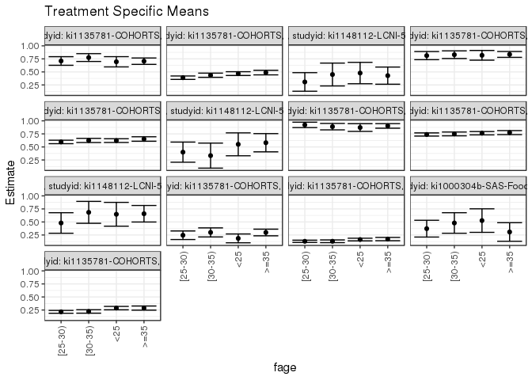

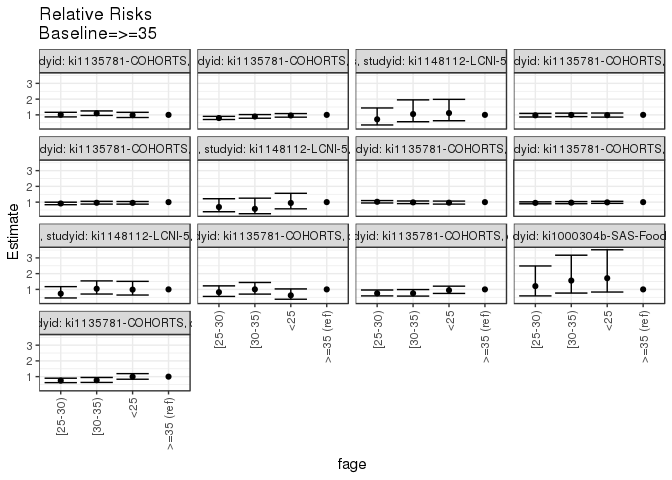

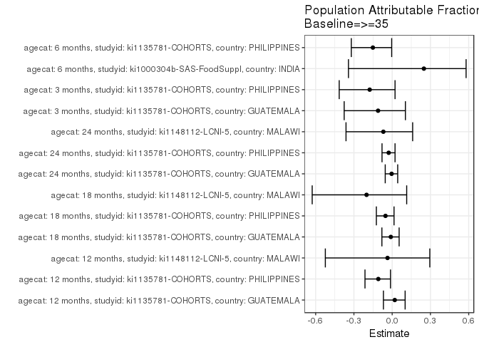

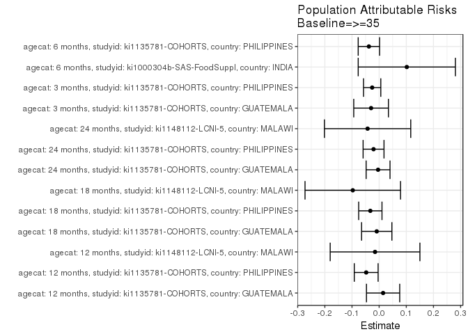

## Results Table

### Parameter: TSM

| agecat | studyid | country | intervention_level | baseline_level | estimate | ci_lower | ci_upper |
| --- | --- | --- | --- | --- | --- | --- | --- |
| 3 months | ki1135781-COHORTS | GUATEMALA | >=35 | NA | 0.2979798 | 0.2342085 | 0.3617511 |
| 3 months | ki1135781-COHORTS | GUATEMALA | <25 | NA | 0.1851852 | 0.1005054 | 0.2698650 |
| 3 months | ki1135781-COHORTS | GUATEMALA | [25-30) | NA | 0.2452830 | 0.1632927 | 0.3272734 |
| 3 months | ki1135781-COHORTS | GUATEMALA | [30-35) | NA | 0.2990654 | 0.2122254 | 0.3859054 |
| 3 months | ki1135781-COHORTS | PHILIPPINES | >=35 | NA | 0.1719039 | 0.1401054 | 0.2037024 |
| 3 months | ki1135781-COHORTS | PHILIPPINES | <25 | NA | 0.1627329 | 0.1372298 | 0.1882361 |
| 3 months | ki1135781-COHORTS | PHILIPPINES | [25-30) | NA | 0.1289308 | 0.1076616 | 0.1502001 |
| 3 months | ki1135781-COHORTS | PHILIPPINES | [30-35) | NA | 0.1294299 | 0.1036002 | 0.1552595 |
| 6 months | ki1000304b-SAS-FoodSuppl | INDIA | >=35 | NA | 0.3076923 | 0.1294350 | 0.4859496 |
| 6 months | ki1000304b-SAS-FoodSuppl | INDIA | <25 | NA | 0.5263158 | 0.3007273 | 0.7519043 |
| 6 months | ki1000304b-SAS-FoodSuppl | INDIA | [25-30) | NA | 0.3714286 | 0.2105838 | 0.5322734 |
| 6 months | ki1000304b-SAS-FoodSuppl | INDIA | [30-35) | NA | 0.4800000 | 0.2832212 | 0.6767788 |
| 6 months | ki1135781-COHORTS | PHILIPPINES | >=35 | NA | 0.2874016 | 0.2480408 | 0.3267623 |
| 6 months | ki1135781-COHORTS | PHILIPPINES | <25 | NA | 0.2866848 | 0.2540085 | 0.3193610 |
| 6 months | ki1135781-COHORTS | PHILIPPINES | [25-30) | NA | 0.2151030 | 0.1878570 | 0.2423489 |
| 6 months | ki1135781-COHORTS | PHILIPPINES | [30-35) | NA | 0.2224080 | 0.1890709 | 0.2557452 |
| 12 months | ki1135781-COHORTS | GUATEMALA | >=35 | NA | 0.7056075 | 0.6444863 | 0.7667287 |
| 12 months | ki1135781-COHORTS | GUATEMALA | <25 | NA | 0.6941176 | 0.5960698 | 0.7921655 |
| 12 months | ki1135781-COHORTS | GUATEMALA | [25-30) | NA | 0.7094017 | 0.6270537 | 0.7917498 |
| 12 months | ki1135781-COHORTS | GUATEMALA | [30-35) | NA | 0.7750000 | 0.7002166 | 0.8497834 |
| 12 months | ki1135781-COHORTS | PHILIPPINES | >=35 | NA | 0.4869739 | 0.4431106 | 0.5308373 |
| 12 months | ki1135781-COHORTS | PHILIPPINES | <25 | NA | 0.4677641 | 0.4315372 | 0.5039909 |
| 12 months | ki1135781-COHORTS | PHILIPPINES | [25-30) | NA | 0.3892774 | 0.3566459 | 0.4219089 |
| 12 months | ki1135781-COHORTS | PHILIPPINES | [30-35) | NA | 0.4363328 | 0.3962745 | 0.4763910 |
| 12 months | ki1148112-LCNI-5 | MALAWI | >=35 | NA | 0.4285714 | 0.2638293 | 0.5933136 |
| 12 months | ki1148112-LCNI-5 | MALAWI | <25 | NA | 0.4782609 | 0.2731251 | 0.6833966 |
| 12 months | ki1148112-LCNI-5 | MALAWI | [25-30) | NA | 0.3076923 | 0.1294268 | 0.4859578 |
| 12 months | ki1148112-LCNI-5 | MALAWI | [30-35) | NA | 0.4500000 | 0.2309119 | 0.6690881 |
| 18 months | ki1135781-COHORTS | GUATEMALA | >=35 | NA | 0.8352941 | 0.7794727 | 0.8911156 |
| 18 months | ki1135781-COHORTS | GUATEMALA | <25 | NA | 0.8181818 | 0.7250232 | 0.9113404 |
| 18 months | ki1135781-COHORTS | GUATEMALA | [25-30) | NA | 0.8125000 | 0.7343322 | 0.8906678 |
| 18 months | ki1135781-COHORTS | GUATEMALA | [30-35) | NA | 0.8300000 | 0.7562920 | 0.9037080 |
| 18 months | ki1135781-COHORTS | PHILIPPINES | >=35 | NA | 0.6518987 | 0.6090057 | 0.6947918 |
| 18 months | ki1135781-COHORTS | PHILIPPINES | <25 | NA | 0.6213873 | 0.5852414 | 0.6575332 |
| 18 months | ki1135781-COHORTS | PHILIPPINES | [25-30) | NA | 0.5956416 | 0.5621668 | 0.6291165 |
| 18 months | ki1135781-COHORTS | PHILIPPINES | [30-35) | NA | 0.6245552 | 0.5845125 | 0.6645979 |
| 18 months | ki1148112-LCNI-5 | MALAWI | >=35 | NA | 0.5806452 | 0.4059773 | 0.7553130 |
| 18 months | ki1148112-LCNI-5 | MALAWI | <25 | NA | 0.5500000 | 0.3307598 | 0.7692402 |
| 18 months | ki1148112-LCNI-5 | MALAWI | [25-30) | NA | 0.4000000 | 0.2068996 | 0.5931004 |
| 18 months | ki1148112-LCNI-5 | MALAWI | [30-35) | NA | 0.3333333 | 0.0934524 | 0.5732142 |
| 24 months | ki1135781-COHORTS | GUATEMALA | >=35 | NA | 0.9028571 | 0.8589311 | 0.9467832 |
| 24 months | ki1135781-COHORTS | GUATEMALA | <25 | NA | 0.8717949 | 0.7975206 | 0.9460691 |
| 24 months | ki1135781-COHORTS | GUATEMALA | [25-30) | NA | 0.9223301 | 0.8705841 | 0.9740761 |
| 24 months | ki1135781-COHORTS | GUATEMALA | [30-35) | NA | 0.8888889 | 0.8269147 | 0.9508631 |
| 24 months | ki1135781-COHORTS | PHILIPPINES | >=35 | NA | 0.7748344 | 0.7363627 | 0.8133062 |
| 24 months | ki1135781-COHORTS | PHILIPPINES | <25 | NA | 0.7628866 | 0.7308896 | 0.7948836 |
| 24 months | ki1135781-COHORTS | PHILIPPINES | [25-30) | NA | 0.7385378 | 0.7082136 | 0.7688620 |
| 24 months | ki1135781-COHORTS | PHILIPPINES | [30-35) | NA | 0.7495430 | 0.7132262 | 0.7858597 |
| 24 months | ki1148112-LCNI-5 | MALAWI | >=35 | NA | 0.6571429 | 0.4990638 | 0.8152219 |
| 24 months | ki1148112-LCNI-5 | MALAWI | <25 | NA | 0.6470588 | 0.4186986 | 0.8754191 |
| 24 months | ki1148112-LCNI-5 | MALAWI | [25-30) | NA | 0.4800000 | 0.2831324 | 0.6768676 |
| 24 months | ki1148112-LCNI-5 | MALAWI | [30-35) | NA | 0.6842105 | 0.4741044 | 0.8943167 |

### Parameter: E(Y)

| agecat | studyid | country | intervention_level | baseline_level | estimate | ci_lower | ci_upper |
| --- | --- | --- | --- | --- | --- | --- | --- |
| 3 months | ki1135781-COHORTS | GUATEMALA | NA | NA | 0.2682927 | 0.2645277 | 0.2720577 |
| 3 months | ki1135781-COHORTS | PHILIPPINES | NA | NA | 0.1461512 | 0.1454719 | 0.1468306 |
| 6 months | ki1000304b-SAS-FoodSuppl | INDIA | NA | NA | 0.4095238 | 0.3937896 | 0.4252580 |
| 6 months | ki1135781-COHORTS | PHILIPPINES | NA | NA | 0.2496318 | 0.2483366 | 0.2509271 |
| 12 months | ki1135781-COHORTS | GUATEMALA | NA | NA | 0.7201493 | 0.7176204 | 0.7226781 |
| 12 months | ki1135781-COHORTS | PHILIPPINES | NA | NA | 0.4392523 | 0.4378094 | 0.4406953 |
| 12 months | ki1148112-LCNI-5 | MALAWI | NA | NA | 0.4134615 | 0.4011578 | 0.4257653 |
| 18 months | ki1135781-COHORTS | GUATEMALA | NA | NA | 0.8263889 | 0.8255064 | 0.8272714 |
| 18 months | ki1135781-COHORTS | PHILIPPINES | NA | NA | 0.6194205 | 0.6186589 | 0.6201821 |
| 18 months | ki1148112-LCNI-5 | MALAWI | NA | NA | 0.4835165 | 0.4630442 | 0.5039888 |
| 24 months | ki1135781-COHORTS | GUATEMALA | NA | NA | 0.8989011 | 0.8973673 | 0.9004349 |
| 24 months | ki1135781-COHORTS | PHILIPPINES | NA | NA | 0.7542237 | 0.7536924 | 0.7547549 |
| 24 months | ki1148112-LCNI-5 | MALAWI | NA | NA | 0.6145833 | 0.5983419 | 0.6308248 |

### Parameter: RR

| agecat | studyid | country | intervention_level | baseline_level | estimate | ci_lower | ci_upper |
| --- | --- | --- | --- | --- | --- | --- | --- |
| 3 months | ki1135781-COHORTS | GUATEMALA | >=35 | >=35 | 1.0000000 | 1.0000000 | 1.0000000 |
| 3 months | ki1135781-COHORTS | GUATEMALA | <25 | >=35 | 0.6214689 | 0.3751071 | 1.0296356 |
| 3 months | ki1135781-COHORTS | GUATEMALA | [25-30) | >=35 | 0.8231532 | 0.5534844 | 1.2242101 |
| 3 months | ki1135781-COHORTS | GUATEMALA | [30-35) | >=35 | 1.0036433 | 0.6997163 | 1.4395832 |
| 3 months | ki1135781-COHORTS | PHILIPPINES | >=35 | >=35 | 1.0000000 | 1.0000000 | 1.0000000 |
| 3 months | ki1135781-COHORTS | PHILIPPINES | <25 | >=35 | 0.9466506 | 0.7428466 | 1.2063694 |
| 3 months | ki1135781-COHORTS | PHILIPPINES | [25-30) | >=35 | 0.7500169 | 0.5853695 | 0.9609749 |
| 3 months | ki1135781-COHORTS | PHILIPPINES | [30-35) | >=35 | 0.7529201 | 0.5735531 | 0.9883805 |
| 6 months | ki1000304b-SAS-FoodSuppl | INDIA | >=35 | >=35 | 1.0000000 | 1.0000000 | 1.0000000 |
| 6 months | ki1000304b-SAS-FoodSuppl | INDIA | <25 | >=35 | 1.7105263 | 0.8320572 | 3.5164653 |
| 6 months | ki1000304b-SAS-FoodSuppl | INDIA | [25-30) | >=35 | 1.2071429 | 0.5856460 | 2.4881822 |
| 6 months | ki1000304b-SAS-FoodSuppl | INDIA | [30-35) | >=35 | 1.5600000 | 0.7671842 | 3.1721196 |
| 6 months | ki1135781-COHORTS | PHILIPPINES | >=35 | >=35 | 1.0000000 | 1.0000000 | 1.0000000 |
| 6 months | ki1135781-COHORTS | PHILIPPINES | <25 | >=35 | 0.9975060 | 0.8347057 | 1.1920586 |
| 6 months | ki1135781-COHORTS | PHILIPPINES | [25-30) | >=35 | 0.7484405 | 0.6210697 | 0.9019328 |
| 6 months | ki1135781-COHORTS | PHILIPPINES | [30-35) | >=35 | 0.7738581 | 0.6316603 | 0.9480670 |
| 12 months | ki1135781-COHORTS | GUATEMALA | >=35 | >=35 | 1.0000000 | 1.0000000 | 1.0000000 |
| 12 months | ki1135781-COHORTS | GUATEMALA | <25 | >=35 | 0.9837164 | 0.8335034 | 1.1610006 |
| 12 months | ki1135781-COHORTS | GUATEMALA | [25-30) | >=35 | 1.0053773 | 0.8698142 | 1.1620681 |
| 12 months | ki1135781-COHORTS | GUATEMALA | [30-35) | >=35 | 1.0983444 | 0.9647684 | 1.2504145 |
| 12 months | ki1135781-COHORTS | PHILIPPINES | >=35 | >=35 | 1.0000000 | 1.0000000 | 1.0000000 |
| 12 months | ki1135781-COHORTS | PHILIPPINES | <25 | >=35 | 0.9605525 | 0.8529646 | 1.0817110 |
| 12 months | ki1135781-COHORTS | PHILIPPINES | [25-30) | >=35 | 0.7993803 | 0.7068315 | 0.9040470 |
| 12 months | ki1135781-COHORTS | PHILIPPINES | [30-35) | >=35 | 0.8960084 | 0.7878719 | 1.0189869 |
| 12 months | ki1148112-LCNI-5 | MALAWI | >=35 | >=35 | 1.0000000 | 1.0000000 | 1.0000000 |
| 12 months | ki1148112-LCNI-5 | MALAWI | <25 | >=35 | 1.1159420 | 0.6273409 | 1.9850875 |
| 12 months | ki1148112-LCNI-5 | MALAWI | [25-30) | >=35 | 0.7179487 | 0.3582072 | 1.4389728 |
| 12 months | ki1148112-LCNI-5 | MALAWI | [30-35) | >=35 | 1.0500000 | 0.5646609 | 1.9524994 |
| 18 months | ki1135781-COHORTS | GUATEMALA | >=35 | >=35 | 1.0000000 | 1.0000000 | 1.0000000 |
| 18 months | ki1135781-COHORTS | GUATEMALA | <25 | >=35 | 0.9795134 | 0.8583674 | 1.1177575 |
| 18 months | ki1135781-COHORTS | GUATEMALA | [25-30) | >=35 | 0.9727113 | 0.8651885 | 1.0935966 |
| 18 months | ki1135781-COHORTS | GUATEMALA | [30-35) | >=35 | 0.9936620 | 0.8891411 | 1.1104695 |
| 18 months | ki1135781-COHORTS | PHILIPPINES | >=35 | >=35 | 1.0000000 | 1.0000000 | 1.0000000 |
| 18 months | ki1135781-COHORTS | PHILIPPINES | <25 | >=35 | 0.9531960 | 0.8730537 | 1.0406950 |
| 18 months | ki1135781-COHORTS | PHILIPPINES | [25-30) | >=35 | 0.9137027 | 0.8379630 | 0.9962882 |
| 18 months | ki1135781-COHORTS | PHILIPPINES | [30-35) | >=35 | 0.9580555 | 0.8739621 | 1.0502404 |
| 18 months | ki1148112-LCNI-5 | MALAWI | >=35 | >=35 | 1.0000000 | 1.0000000 | 1.0000000 |
| 18 months | ki1148112-LCNI-5 | MALAWI | <25 | >=35 | 0.9472222 | 0.5748716 | 1.5607485 |
| 18 months | ki1148112-LCNI-5 | MALAWI | [25-30) | >=35 | 0.6888889 | 0.3900500 | 1.2166849 |
| 18 months | ki1148112-LCNI-5 | MALAWI | [30-35) | >=35 | 0.5740741 | 0.2631630 | 1.2523077 |
| 24 months | ki1135781-COHORTS | GUATEMALA | >=35 | >=35 | 1.0000000 | 1.0000000 | 1.0000000 |
| 24 months | ki1135781-COHORTS | GUATEMALA | <25 | >=35 | 0.9655956 | 0.8753599 | 1.0651331 |
| 24 months | ki1135781-COHORTS | GUATEMALA | [25-30) | >=35 | 1.0215681 | 0.9484541 | 1.1003183 |
| 24 months | ki1135781-COHORTS | GUATEMALA | [30-35) | >=35 | 0.9845288 | 0.9042856 | 1.0718926 |
| 24 months | ki1135781-COHORTS | PHILIPPINES | >=35 | >=35 | 1.0000000 | 1.0000000 | 1.0000000 |
| 24 months | ki1135781-COHORTS | PHILIPPINES | <25 | >=35 | 0.9845801 | 0.9226222 | 1.0506988 |
| 24 months | ki1135781-COHORTS | PHILIPPINES | [25-30) | >=35 | 0.9531556 | 0.8936806 | 1.0165887 |
| 24 months | ki1135781-COHORTS | PHILIPPINES | [30-35) | >=35 | 0.9673589 | 0.9025235 | 1.0368518 |
| 24 months | ki1148112-LCNI-5 | MALAWI | >=35 | >=35 | 1.0000000 | 1.0000000 | 1.0000000 |
| 24 months | ki1148112-LCNI-5 | MALAWI | <25 | >=35 | 0.9846547 | 0.6423832 | 1.5092937 |
| 24 months | ki1148112-LCNI-5 | MALAWI | [25-30) | >=35 | 0.7304348 | 0.4540280 | 1.1751146 |
| 24 months | ki1148112-LCNI-5 | MALAWI | [30-35) | >=35 | 1.0411899 | 0.7048871 | 1.5379433 |

### Parameter: PAR

| agecat | studyid | country | intervention_level | baseline_level | estimate | ci_lower | ci_upper |
| --- | --- | --- | --- | --- | --- | --- | --- |
| 3 months | ki1135781-COHORTS | GUATEMALA | >=35 | NA | -0.0296871 | -0.0935695 | 0.0341953 |
| 3 months | ki1135781-COHORTS | PHILIPPINES | >=35 | NA | -0.0257526 | -0.0575584 | 0.0060531 |
| 6 months | ki1000304b-SAS-FoodSuppl | INDIA | >=35 | NA | 0.1018315 | -0.0771188 | 0.2807818 |
| 6 months | ki1135781-COHORTS | PHILIPPINES | >=35 | NA | -0.0377698 | -0.0771518 | 0.0016123 |
| 12 months | ki1135781-COHORTS | GUATEMALA | >=35 | NA | 0.0145418 | -0.0466317 | 0.0757152 |
| 12 months | ki1135781-COHORTS | PHILIPPINES | >=35 | NA | -0.0477216 | -0.0916087 | -0.0038346 |
| 12 months | ki1148112-LCNI-5 | MALAWI | >=35 | NA | -0.0151099 | -0.1803108 | 0.1500911 |
| 18 months | ki1135781-COHORTS | GUATEMALA | >=35 | NA | -0.0089052 | -0.0647337 | 0.0469232 |
| 18 months | ki1135781-COHORTS | PHILIPPINES | >=35 | NA | -0.0324782 | -0.0753780 | 0.0104216 |
| 18 months | ki1148112-LCNI-5 | MALAWI | >=35 | NA | -0.0971287 | -0.2729922 | 0.0787348 |
| 24 months | ki1135781-COHORTS | GUATEMALA | >=35 | NA | -0.0039560 | -0.0479088 | 0.0399967 |
| 24 months | ki1135781-COHORTS | PHILIPPINES | >=35 | NA | -0.0206108 | -0.0590862 | 0.0178646 |
| 24 months | ki1148112-LCNI-5 | MALAWI | >=35 | NA | -0.0425595 | -0.2014708 | 0.1163517 |

### Parameter: PAF

| agecat | studyid | country | intervention_level | baseline_level | estimate | ci_lower | ci_upper |
| --- | --- | --- | --- | --- | --- | --- | --- |
| 3 months | ki1135781-COHORTS | GUATEMALA | >=35 | NA | -0.1106520 | -0.3763280 | 0.1037399 |
| 3 months | ki1135781-COHORTS | PHILIPPINES | >=35 | NA | -0.1762054 | -0.4152839 | 0.0224864 |
| 6 months | ki1000304b-SAS-FoodSuppl | INDIA | >=35 | NA | 0.2486583 | -0.3427423 | 0.5795810 |
| 6 months | ki1135781-COHORTS | PHILIPPINES | >=35 | NA | -0.1513019 | -0.3204141 | -0.0038487 |
| 12 months | ki1135781-COHORTS | GUATEMALA | >=35 | NA | 0.0201927 | -0.0685406 | 0.1015575 |
| 12 months | ki1135781-COHORTS | PHILIPPINES | >=35 | NA | -0.1086428 | -0.2132100 | -0.0130884 |
| 12 months | ki1148112-LCNI-5 | MALAWI | >=35 | NA | -0.0365449 | -0.5241569 | 0.2950691 |
| 18 months | ki1135781-COHORTS | GUATEMALA | >=35 | NA | -0.0107761 | -0.0806422 | 0.0545730 |
| 18 months | ki1135781-COHORTS | PHILIPPINES | >=35 | NA | -0.0524332 | -0.1240221 | 0.0145962 |
| 18 months | ki1148112-LCNI-5 | MALAWI | >=35 | NA | -0.2008798 | -0.6271603 | 0.1137246 |
| 24 months | ki1135781-COHORTS | GUATEMALA | >=35 | NA | -0.0044010 | -0.0545071 | 0.0433243 |
| 24 months | ki1135781-COHORTS | PHILIPPINES | >=35 | NA | -0.0273272 | -0.0796285 | 0.0224405 |
| 24 months | ki1148112-LCNI-5 | MALAWI | >=35 | NA | -0.0692494 | -0.3620069 | 0.1605811 |